# Clustering

Dataset from Kaggle https://www.kaggle.com/datasets/dhruvildave/ookla-internet-speed-dataset

## Description

This dataset provides global fixed broadband and mobile (cellular) network performance metrics in zoom level 16 web mercator tiles (approximately 610.8 meters by 610.8 meters at the equator). Data is provided in both Shapefile format as well as Apache Parquet with geometries represented in Well Known Text (WKT) projected in EPSG:4326. Download speed, upload speed, and latency are collected via the Speedtest by Ookla applications for Android and iOS and averaged for each tile. Measurements are filtered to results containing GPS-quality location accuracy.

### Schema

avg_d_kbps Integer: The average download speed of all tests performed in the tile, represented in kilobits per second.

avg_u_kbps Integer: The average upload speed of all tests performed in the tile, represented in kilobits per second.

avg_lat_ms Integer: The average latency of all tests performed in the tile, represented in milliseconds.

tests Integer: The number of tests taken in the tile.

devices Integer: The number of unique devices contributing tests in the tile.

quadkey Text: The quadkey representing the tile.

tile Text: Well Known Text (WKT) representation of the tile geometry.

Quadkeys can act as a unique identifier for the tile. This can be useful for joining data spatially from multiple periods (quarters), creating coarser spatial aggregations without using geospatial functions, spatial indexing, partitioning, and an alternative for storing and deriving the tile geometry.

### Goal

Find clusters for the dataset. For example: Regions with the highest download speeds, regions with the highest upload speeds, regions with the highest latency, etc.

```python
import os
memory = '8g'
pyspark_submit_args = ' --driver-memory ' + memory + ' pyspark-shell'
os.environ["PYSPARK_SUBMIT_ARGS"] = pyspark_submit_args
```

```python
# Install shapely to deal with geospatial data
!pip install shapely
```

```python
!kaggle datasets download -d dhruvildave/ookla-internet-speed-dataset -f "2020-q2/2020-04-01_performance_mobile_tiles.parquet"
!unzip 2020-04-01_performance_mobile_tiles.parquet.zip
!rm 2020-04-01_performance_mobile_tiles.parquet.zip
```

[output not shown]

```python
# initlize pyspark
from pyspark.sql import SparkSession
spark = SparkSession.builder.appName("internet-analysis-clustering").getOrCreate()
```

[output not shown]

```python
# Needed to make Jupyter work with Gitpod
import plotly.io as pio
pio.renderers.default = 'iframe_connected'
```

```python
from shapely import wkt
from pyspark.sql.types import StringType
from pyspark.sql.types import DoubleType
from pyspark.sql.functions import udf


@udf(returnType=DoubleType())
def longitude(polygon: str):
    return wkt.loads(polygon).centroid.x

@udf(returnType=DoubleType())
def latitude(polygon):
    return wkt.loads(polygon).centroid.y
```

```
root
 |-- quadkey: string (nullable = true)
 |-- tile: string (nullable = true)
 |-- avg_d_kbps: long (nullable = true)
 |-- avg_u_kbps: long (nullable = true)
 |-- avg_lat_ms: long (nullable = true)
 |-- tests: long (nullable = true)
 |-- devices: long (nullable = true)

+----------------+--------------------+----------+----------+----------+-----+-------+
|         quadkey|                tile|avg_d_kbps|avg_u_kbps|avg_lat_ms|tests|devices|
+----------------+--------------------+----------+----------+----------+-----+-------+
|1203022122320032|POLYGON((24.09301...|     28772|      3165|        34|    8|      1|
|0313113213321131|POLYGON((-1.49963...|     20782|     10180|        54|    2|      2|
|1221210331312333|POLYGON((30.88806...|     22690|     22416|       449|    6|      2|
|1200312211223323|POLYGON((18.00109...|     54493|      4635|        21|    2|      2|
|0302233220203221|POLYGON((-81.5130...|     90669|      6576|        21|    1|      1|
+----------------+--------------------+----------+----------+----------+-----+-------+
only showing top 5 rows
```

```
root
 |-- avg_d_kbps: integer (nullable = true)
 |-- avg_u_kbps: integer (nullable = true)
 |-- avg_lat_ms: integer (nullable = true)
 |-- tests: integer (nullable = true)
 |-- devices: integer (nullable = true)
 |-- longitude: double (nullable = true)
 |-- latitude: double (nullable = true)
```

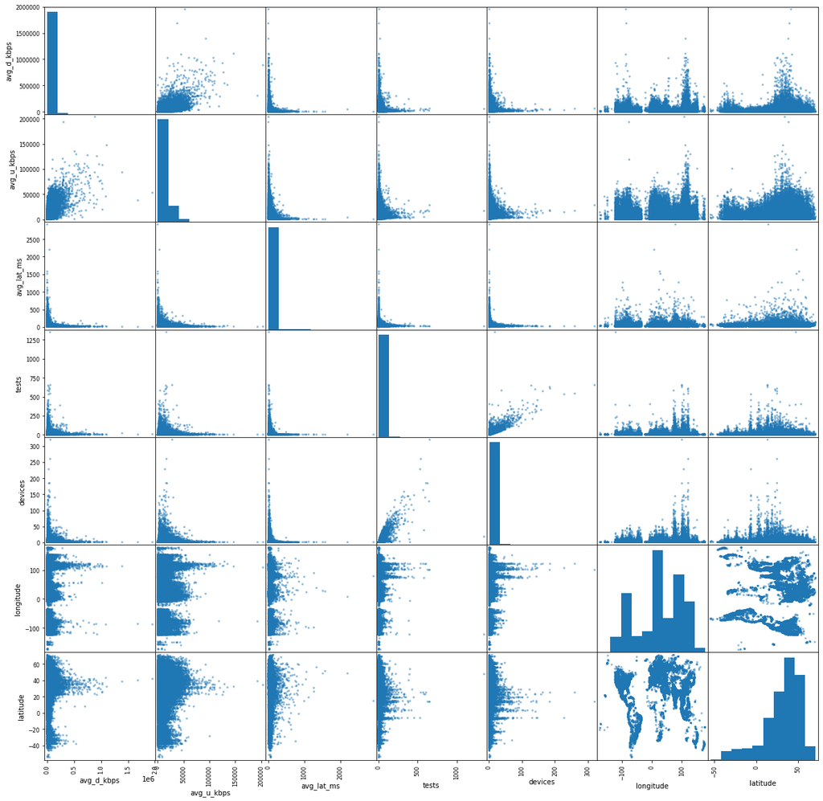

```python
import pandas as pd
# Read the data into a dataframe and print the schema
df = spark.read.parquet("2020-04-01_performance_mobile_tiles.parquet")
df.printSchema()

# Print the first 5 rows of the dataframe
df.show(5)

# We will use only a fractions of the data.
df = df.sample(fraction=0.01)

# Drop null values
df = df.dropna()

# Adds two columns: longitude and latitude
df = df.withColumn("longitude", longitude(df.tile))
df = df.withColumn("latitude", latitude(df.tile))

# Remove the "quadkey" and "tile" columns
df = df.drop("tile")
df = df.drop("quadkey")

# Save the DataFrame as a CSV file
df.toPandas().to_csv("internet-analysis-clustering.csv", index=False, header=True)

pd.plotting.scatter_matrix(df.toPandas(), figsize=(20, 20))

df = spark.read.csv("internet-analysis-clustering.csv", header=True, inferSchema=True)
df.printSchema()
```

# Insight from Scatter Matrix

It seems that we can cluster the data based on the following features:

- Upload
- Download
- Longitude
- Latitude

```python
df_interested = df.drop("devices", "tests", "avg_lat_ms")

df_interested.printSchema()
```

```
root
 |-- avg_d_kbps: integer (nullable = true)
 |-- avg_u_kbps: integer (nullable = true)
 |-- longitude: double (nullable = true)
 |-- latitude: double (nullable = true)
```

# Pipeline

As usual, we generate the features vector using VectorAssembler

Then we apply MinMax Normalization using MinMaxScaler

```python
from pyspark.ml.feature import VectorAssembler
from pyspark.ml.feature import MinMaxScaler

assembler = VectorAssembler(inputCols=["avg_d_kbps", "avg_u_kbps", "latitude", "longitude"], outputCol="features")

scaler = MinMaxScaler(inputCol="features", outputCol="scaledFeatures")
```

```python
from pyspark.ml.clustering import KMeans
from pyspark.ml.evaluation import ClusteringEvaluator
from pyspark.ml import Pipeline

kmeans = KMeans(featuresCol="scaledFeatures").setK(3)

preprocessor = Pipeline(stages=[assembler, scaler])

preprocessed_model = preprocessor.fit(df_interested)

preprocessed_df = preprocessed_model.transform(df_interested)

preprocessed_df.show(5)

ks = range(2, 11)
sse = []

for k in ks:
    kmeans_model = kmeans.setK(k).fit(preprocessed_df)
    sse.append(kmeans_model.summary.trainingCost)
    predictions = kmeans_model.transform(preprocessed_df)
    evaluator = ClusteringEvaluator(metricName="silhouette")
    silhouette = evaluator.evaluate(predictions)
    print("For k =", k, "The average silhouette score is", silhouette)
```

```
+----------+----------+-------------------+-------------------+--------------------+--------------------+
|avg_d_kbps|avg_u_kbps|          longitude|           latitude|            features|      scaledFeatures|
+----------+----------+-------------------+-------------------+--------------------+--------------------+
|     20938|      8086| -46.57928466796875|-23.420408155393552|[20938.0,8086.0,-...|[0.01071803020870...|
|      3711|      2089|-3.7765502929687496|  40.42813288138676|[3711.0,2089.0,40...|[0.00189879509190...|
|    129904|     16393|  45.85968017578125|   25.1925150898351|[129904.0,16393.0...|[0.06650236722256...|
|      8022|      5844| -46.43646240234374|-23.556434219092246|[8022.0,5844.0,-2...|[0.00410577962714...|
|     27190|     18345| -99.12139892578125|     16.71775455834|[27190.0,18345.0,...|[0.01391869532453...|
+----------+----------+-------------------+-------------------+--------------------+--------------------+
only showing top 5 rows

For k = 2 The average silhouette score is 0.07874895451967366
For k = 3 The average silhouette score is -0.5440829710767203
For k = 4 The average silhouette score is -0.5494379791214957
For k = 5 The average silhouette score is -0.5382567939403476
For k = 6 The average silhouette score is -0.5465876960925484
For k = 7 The average silhouette score is -0.5997840214243625
For k = 8 The average silhouette score is -0.36809350772616756
For k = 9 The average silhouette score is -0.4764182117285401
For k = 10 The average silhouette score is -0.39643146268664253
```

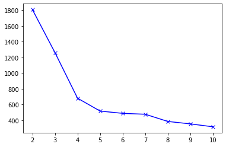

```python
import matplotlib.pyplot as plt

# Scatter plot with a line connecting the points and blue x and y axis legends
plt.plot(ks, sse, 'bx-')
```

# Conclusion

K-means is a bad choice for clustering geospatial data, because of the distortion of the Earth.